# chapter3

Milja von Lerber

8 helmikuuta 2017

# Chapter 3

```r
url<- "http://s3.amazonaws.com/assets.datacamp.com/production/course_2218/datasets/alc.txt"
alc <- read.table(url, sep = ",", header = TRUE)
```

Now I will choose 4 interesting variables of the data and see how it affects the amounts the students drink alcohol. I will choose sex of the students, their fathers’ level of education, their relationship status and the quality of their relationship within their families.

My personal hypothesis is that sex will have a minor effect on the amount of alcohol the students use. Men probably will drink more than women.

Whether the father is educated will have no significant relationship with overall usage of alcohol. It is probable though, that when it comes to high consumption, the father will have a lower education.

My personal hypothesis is that students with a romantic relationship won’t drink as much as the ones that don’t.

My hypothesis is as well, that the better relationships students have with their families, the less they will drink.

```r
library(tidyr)
library(dplyr)
```

```r
library(ggplot2)

alc %>% group_by(sex, high_use) %>% summarise(count = n(),father_education =mean(Fedu))
```

```
## Source: local data frame [4 x 4]
## Groups: sex [?]
##
##      sex high_use count father_education
##   <fctr>    <lgl> <int>            <dbl>
## 1      F    FALSE   157         2.496815
## 2      F     TRUE    41         2.585366
## 3      M    FALSE   113         2.646018
## 4      M     TRUE    71         2.577465
```

```r
alc %>% group_by(sex, romantic) %>% summarise(count = n(),alcohol =mean(alc_use))
```

```
## Source: local data frame [4 x 4]
## Groups: sex [?]
##
##      sex romantic count  alcohol
##   <fctr>   <fctr> <int>    <dbl>
## 1      F       no   129 1.627907
## 2      F      yes    69 1.586957
## 3      M       no   132 2.071970
## 4      M      yes    52 2.384615
```

```r
alc %>% group_by(sex, high_use) %>% summarise(count = n(),family_relationships =mean(famrel))
```

```
## Source: local data frame [4 x 4]
## Groups: sex [?]
##
##      sex high_use count family_relationships
##   <fctr>    <lgl> <int>                <dbl>
## 1      F    FALSE   157             3.917197
## 2      F     TRUE    41             3.731707
## 3      M    FALSE   113             4.150442
## 4      M     TRUE    71             3.774648
```

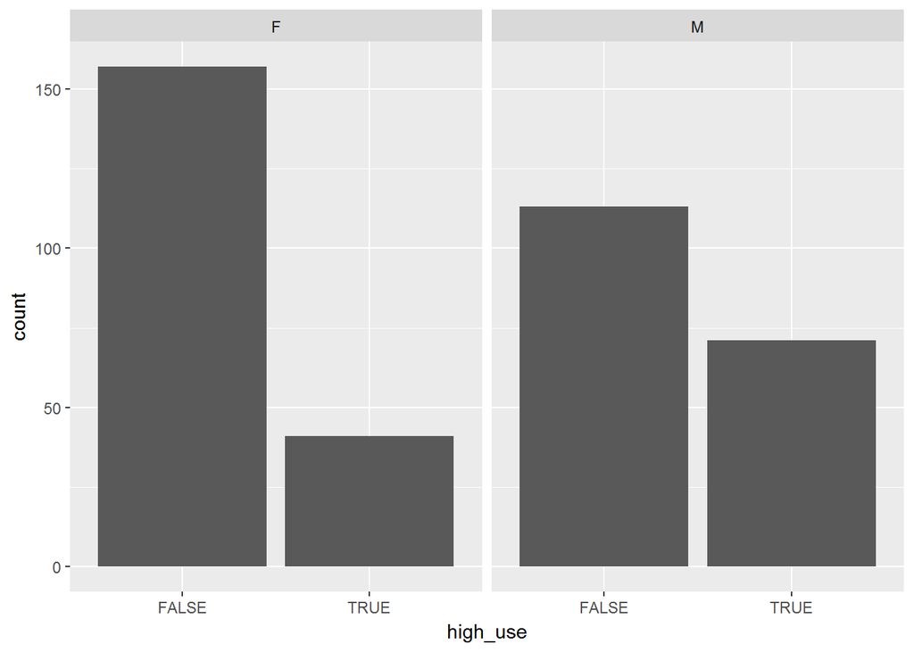

```r
g2 <- ggplot(data = alc, aes(high_use), fill = sex)
g2+geom_bar()+facet_wrap("sex")
```

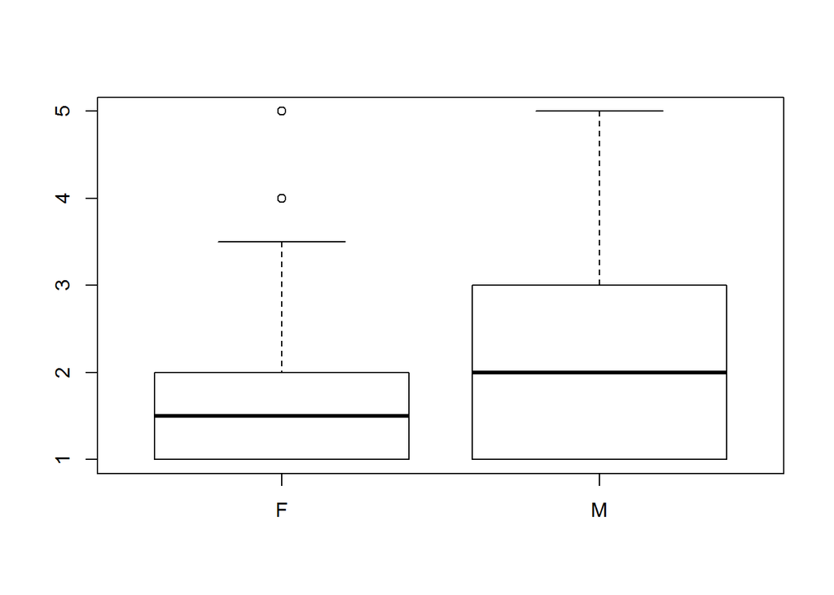

```r
boxplot(alc_use ~ sex, data = alc)
```

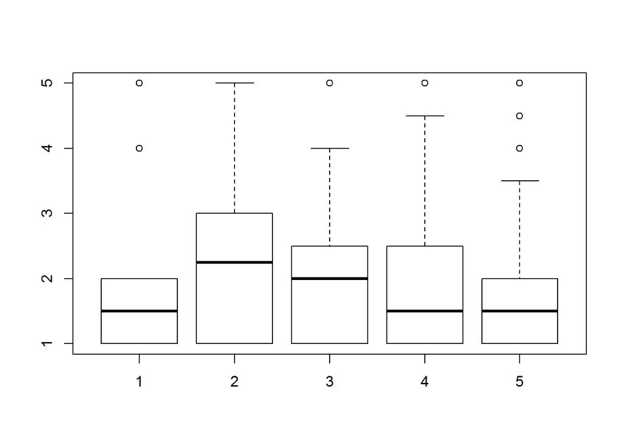

```r
boxplot(alc_use ~ famrel, data = alc)
```

From the numerical summaries as well from the data visualization one can see, that being male definately affects the amount of alcohol students drink.

From the education of father you get different results for girls and boys.For girls those who drink a lot their fathers are more educated whereas when it comes to boys, those who drink a lot have on average a father with a lower education. The differences might mean nothing though: the differences are so minor.

For romantic relationships girls with a romantic elationship drink less, but boys with a relationship drink actually more, which was surprising.This was also hardly significant.

With family relationship the difference of people who use a lot of alcohol and ones who don’t was actually very clear. People with a better relationship with their family rarely drink as much.

```r
m <- glm(high_use ~ sex + romantic+ Fedu + famrel, data = alc, family = "binomial")
summary(m)
```

```
##
## Call:
## glm(formula = high_use ~ sex + romantic + Fedu + famrel, family = "binomial",
##     data = alc)
##
## Deviance Residuals:
##     Min       1Q   Median       3Q      Max
## -1.3813  -0.8701  -0.6725   1.2144   2.0001
##
## Coefficients:
##              Estimate Std. Error z value Pr(>|z|)
## (Intercept)  0.004752   0.564678   0.008  0.99329
## sexM         0.933587   0.236726   3.944 8.02e-05 ***
## romanticyes -0.138636   0.253821  -0.546  0.58493
## Fedu         0.003135   0.105821   0.030  0.97636
## famrel      -0.344807   0.123164  -2.800  0.00512 **
## ---
## Signif. codes:  0 '***' 0.001 '**' 0.01 '*' 0.05 '.' 0.1 ' ' 1
##
## (Dispersion parameter for binomial family taken to be 1)
##
##     Null deviance: 462.21  on 381  degrees of freedom
## Residual deviance: 439.42  on 377  degrees of freedom
## AIC: 449.42
##
## Number of Fisher Scoring iterations: 4
```

Counting confidence intervals:

```r
confint(m)
```

```
##                  2.5 %     97.5 %
## (Intercept) -1.1125448  1.1097143
## sexM         0.4747631  1.4044528
## romanticyes -0.6442339  0.3532360
## Fedu        -0.2044852  0.2112038
## famrel      -0.5885247 -0.1039446
```

```r
m1 <- glm(high_use ~ sex + famrel, data = alc, family = "binomial")
probabilities <- predict(m1, type = "response")
alc <- mutate(alc, probability = probabilities)
alc <- mutate(alc, prediction = probability > 0.5)
table(high_use = alc$high_use, prediction = alc$prediction)
```

```
##         prediction
## high_use FALSE TRUE
##    FALSE   266    4
##    TRUE    104    8
```

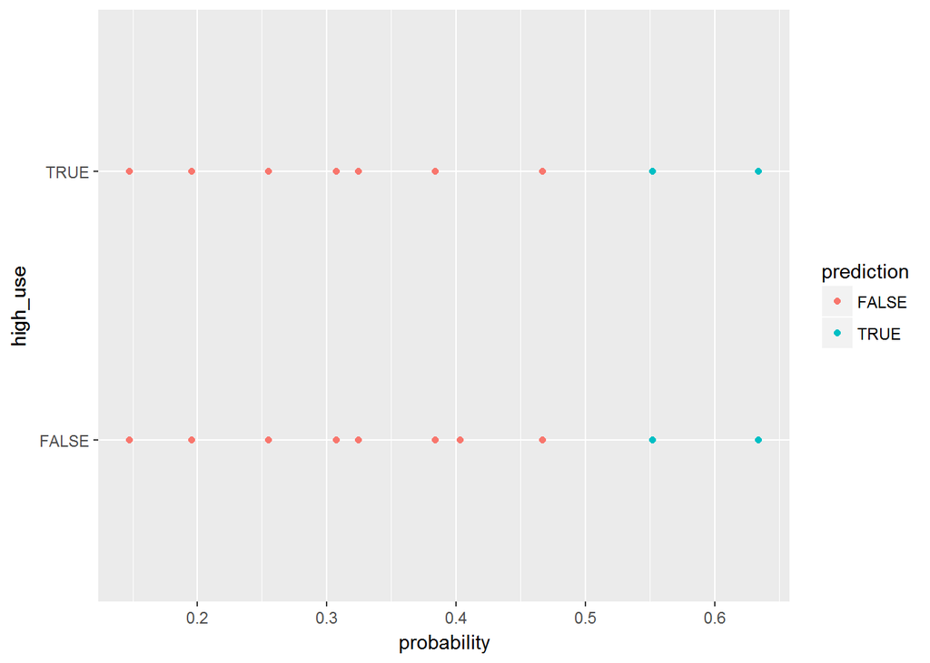

```r
g <- ggplot(alc, aes(x =probability, y = high_use, col = prediction))
g + geom_point()
```

```r
loss_func <- function(class, prob) {
  n_wrong <- abs(class - prob) > 0.5
  mean(n_wrong)
}
loss_func(class = alc$high_use, alc$probability)
```

```
## [1] 0.2827225
```

From the predictions we can see that my model is not very good: almost a third were were falsely predicted. So the prediction power of my model is not very good.

Still, compared to random guessing, my model works better (because if I were to guess, I would have about 0.5 probability to get it right).

Here I’m trying out cross validation.

```r
library(boot)
cv <- cv.glm(data = alc, cost = loss_func, glmfit = m1, 10)
cv$delta[1]
```

```
## [1] 0.2853403
```

My model sadly is not better than the example model in datacamp.

Here I will show how I analyzed the data. First I will look at the names of the variables. This data is collected from students. The point is to analyze their alcohol usage.

```r
colnames(alc)
```

```
##  [1] "school"      "sex"         "age"         "address"     "famsize"
##  [6] "Pstatus"     "Medu"        "Fedu"        "Mjob"        "Fjob"
## [11] "reason"      "nursery"     "internet"    "guardian"    "traveltime"
## [16] "studytime"   "failures"    "schoolsup"   "famsup"      "paid"
## [21] "activities"  "higher"      "romantic"    "famrel"      "freetime"
## [26] "goout"       "Dalc"        "Walc"        "health"      "absences"
## [31] "G1"          "G2"          "G3"          "alc_use"     "high_use"
## [36] "probability" "prediction"
```

Now I will choose 4 interesting variables of the data and see how it affects the amounts the students drink alcohol. I will choose sex of the students, their fathers’ level of education, their relationship status and the quality of their relationship within their families.

My personal hypothesis is that sex will have a minor effect on the amount of alcohol the students use. Men probably will drink more than women.

Whether the father is educated will have no significant relationship with overall usage of alcohol. It is probable though, that when it comes to high consumption, the father will have a lower education.

My personal hypothesis is that students with a romantic relationship won’t drink as much as the ones that don’t.

My hypothesis is as well, that the better relationships students have with their families, the less they will drink.

```r
library(tidyr)
library(dplyr)
library(ggplot2)

alc %>% group_by(sex, high_use) %>% summarise(count = n(),father_education =mean(Fedu))
```

```
## Source: local data frame [4 x 4]
## Groups: sex [?]
##
##      sex high_use count father_education
##   <fctr>    <lgl> <int>            <dbl>
## 1      F    FALSE   157         2.496815
## 2      F     TRUE    41         2.585366
## 3      M    FALSE   113         2.646018
## 4      M     TRUE    71         2.577465
```

```r
alc %>% group_by(sex, romantic) %>% summarise(count = n(),alcohol =mean(alc_use))
```

```
## Source: local data frame [4 x 4]
## Groups: sex [?]
##
##      sex romantic count  alcohol
##   <fctr>   <fctr> <int>    <dbl>
## 1      F       no   129 1.627907
## 2      F      yes    69 1.586957
## 3      M       no   132 2.071970
## 4      M      yes    52 2.384615
```

```r
alc %>% group_by(sex, high_use) %>% summarise(count = n(),family_relationships =mean(famrel))
```

```
## Source: local data frame [4 x 4]
## Groups: sex [?]
##
##      sex high_use count family_relationships
##   <fctr>    <lgl> <int>                <dbl>
## 1      F    FALSE   157             3.917197
## 2      F     TRUE    41             3.731707
## 3      M    FALSE   113             4.150442
## 4      M     TRUE    71             3.774648
```

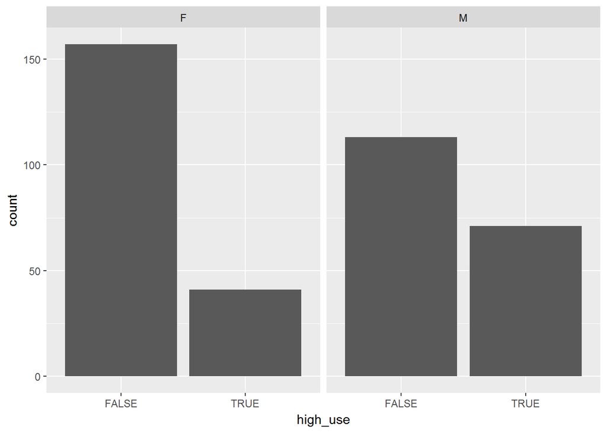

```r
g2 <- ggplot(data = alc, aes(high_use), fill = sex)
g2+geom_bar()+facet_wrap("sex")
```

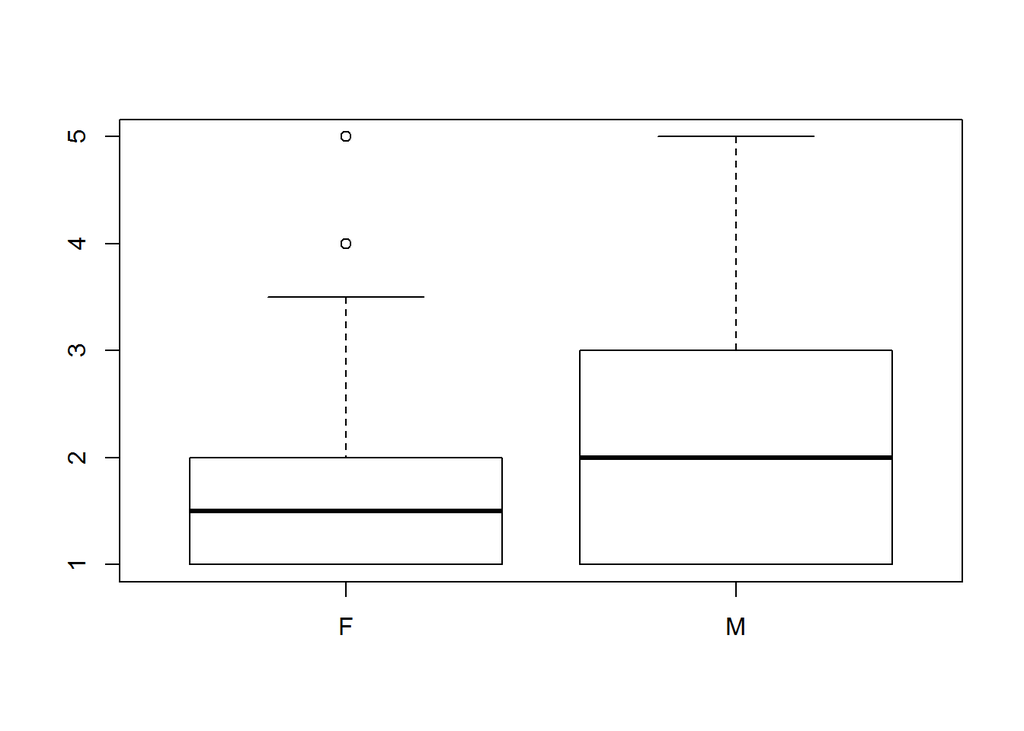

```r
boxplot(alc_use ~ sex, data = alc)
```

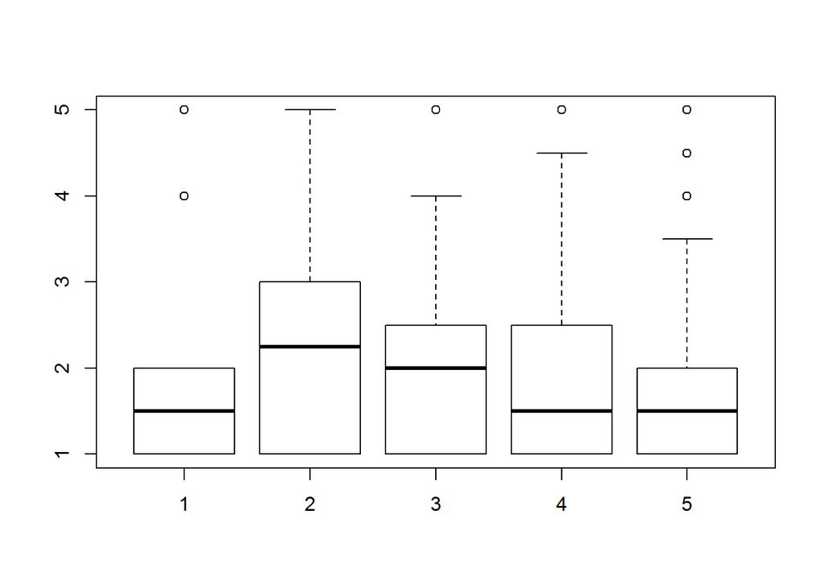

```r
boxplot(alc_use ~ famrel, data = alc)
```

From the numerical summaries as well from the data visualization one can see, that being male definately affects the amount of alcohol students drink.

From the education of father you get different results for girls and boys.For girls those who drink a lot their fathers are more educated whereas when it comes to boys, those who drink a lot have on average a father with a lower education. The differences might mean nothing though: the differences are so minor.

For romantic relationships girls with a romantic elationship drink less, but boys with a relationship drink actually more, which was surprising.This was also hardly significant.

With family relationship the difference of people who use a lot of alcohol and ones who don’t was actually very clear. People with a better relationship with their family rarely drink as much.

```r
m <- glm(high_use ~ sex + romantic+ Fedu + famrel, data = alc, family = "binomial")
summary(m)
```

```
##
## Call:
## glm(formula = high_use ~ sex + romantic + Fedu + famrel, family = "binomial",
##     data = alc)
##
## Deviance Residuals:
##     Min       1Q   Median       3Q      Max
## -1.3813  -0.8701  -0.6725   1.2144   2.0001
##
## Coefficients:
##              Estimate Std. Error z value Pr(>|z|)
## (Intercept)  0.004752   0.564678   0.008  0.99329
## sexM         0.933587   0.236726   3.944 8.02e-05 ***
## romanticyes -0.138636   0.253821  -0.546  0.58493
## Fedu         0.003135   0.105821   0.030  0.97636
## famrel      -0.344807   0.123164  -2.800  0.00512 **
## ---
## Signif. codes:  0 '***' 0.001 '**' 0.01 '*' 0.05 '.' 0.1 ' ' 1
##
## (Dispersion parameter for binomial family taken to be 1)
##
##     Null deviance: 462.21  on 381  degrees of freedom
## Residual deviance: 439.42  on 377  degrees of freedom
## AIC: 449.42
##
## Number of Fisher Scoring iterations: 4
```

Counting confidence intervals:

```r
confint(m)
```

```
##                  2.5 %     97.5 %
## (Intercept) -1.1125448  1.1097143
## sexM         0.4747631  1.4044528
## romanticyes -0.6442339  0.3532360
## Fedu        -0.2044852  0.2112038
## famrel      -0.5885247 -0.1039446
```

```r
m1 <- glm(high_use ~ sex + famrel, data = alc, family = "binomial")
probabilities <- predict(m1, type = "response")
alc <- mutate(alc, probability = probabilities)
alc <- mutate(alc, prediction = probability > 0.5)
table(high_use = alc$high_use, prediction = alc$prediction)
```

```
##         prediction
## high_use FALSE TRUE
##    FALSE   266    4
##    TRUE    104    8
```

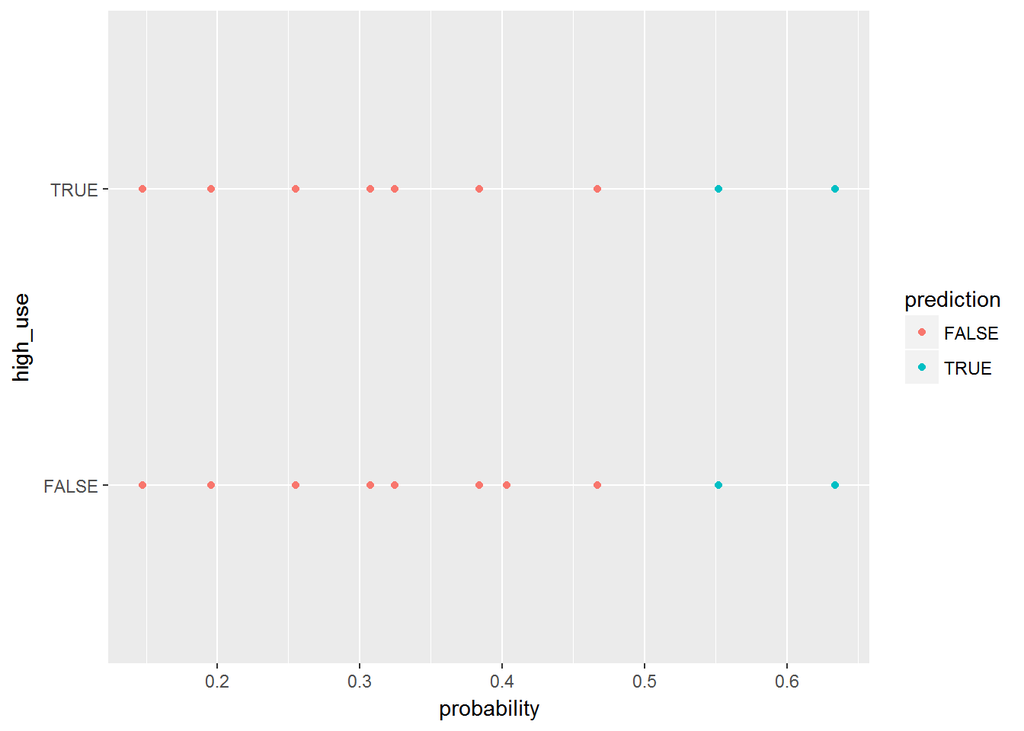

```r
g <- ggplot(alc, aes(x =probability, y = high_use, col = prediction))
g + geom_point()
```

```r
loss_func <- function(class, prob) {
  n_wrong <- abs(class - prob) > 0.5
  mean(n_wrong)
}
loss_func(class = alc$high_use, alc$probability)
```

```
## [1] 0.2827225
```

From the predictions we can see that my model is not very good: almost a third were were falsely predicted. So the prediction power of my model is not very good.

Still, compared to random guessing, my model works better (because if I were to guess, I would have about 0.5 probability to get it right).

Here I’m trying out cross validation.

```r
library(boot)
cv <- cv.glm(data = alc, cost = loss_func, glmfit = m1, 10)
cv$delta[1]
```

```
## [1] 0.2827225
```

My model sadly is not better than the example model in datacamp.